# Extracting insights from FOMC statements

## 5.2 Findings: Text Classification

Text classification of FOMC statements is not generally a research objective but we think it is worthwhile. Classification addresses a potential need: Can a machine correctly infer the opinion or direction of forward guidance or policy decisions in a structured text by the FOMC? In this regard, the classification problem for the FOMC is isomorphic to the Ham-Spam classification of incoming emails by an email program. However, the reader may object that FOMC statements are not so voluminous to require automated processing. Our response is that FOMC statements are merely the first baby step in a much larger classification problem: the public communications of all FOMC and Federal Reserve system members. As previously explained, the FOMC members give speeches, publish articles, appear on TV interviews. Moreover, FOMC meeting minutes are released several weeks after the policy statement is released. These are much longer and required more effort to read and digest. Also, the FOMC transcripts released several years after the meeting may run to over 100 pages each. They contain word for word replay of the entire meeting (excluding private discussions). Lastly, there are at least 16 relevant central banks around the world of interest. Although the Fed is the world’s more important central bank, the ECB, Bank of England, Bank of Japan, Bank of China, Bank of Australia, Bank of New Zealand, all produce communications. In summary, no single person can read all central bank communications. The ability to extract key messages from plain texts remains a valuable capability.

## 5.3 Sentiment Analysis

### 5.3.1 Sentiment Analysis Used

Sentiment analysis is a research branch located at the heart of natural language processing (NLP), computational linguistics and text mining. It refers to any measures by which subjective information is extracted from textual documents. In other words, it extracts the polarity of the expressed opinion in a range spanning from positive to negative. Current research in finance and the social sciences utilizes sentiment analysis to understand human decisions in response to textual materials. This immediately reveals manifold implications for practitioners, as well as those involved in the fields of finance research and the social sciences: researchers can use R to extract text components that are relevant for readers and test their hypotheses on this basis.

[source](https://cran.r-project.org/web/packages/SentimentAnalysis/vignettes/SentimentAnalysis.html#dictionary-generation)

### 5.3.2 Choice of Dictionary for text processing - Loughran-McDonoald

We used Lougran-McDonald Dictionary as our choice of Finance Dictionary for text processing. The Loughran-McDonald Master Dictionary was initially developed in conjunction with **our paper published in Journal of Finance**. The dictionary provides a means of determining which tokens (collections of characters) are actual words,which is important for consistency in word counts.

[source](https://cran.r-project.org/web/packages/SentimentAnalysis/vignettes/SentimentAnalysis.html#dictionary-generation)

### 5.3.3 Methods for Sentiment Analysis

In the process of performing sentiment analysis, one must convert the running text into a machine-readable format. This is achieved by executing a series of preprocessing operations. First, the text is tokenized into single words, followed by what are common preprocessing steps: stopword removal, stemming, removal of punctuation and conversion to lower-case. These operations are also conducted by default in SentimentAnalysis, but can be adapted to oneâs personal needs.

### 5.3.4 Functionality of Sentiment Analysis

The process of Sentiment analysis tokenizes each document and finally converts the input into a document-term matrix. All of the previous operations are undertaken without manual specification. The analyzeSentiment() routine also accepts other input formats in case the user has already performed a preprocessing step or wants to implement a specific set of operations.

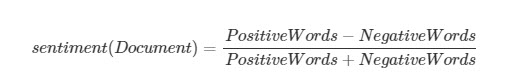

```r
# Reading FOMC Data

fomcStatements <-readRDS(file = "fomc_merged_data_v2.rds") %>% select(statement.dates, statement.content)
```

```r
# Sentimental Analysis

fomcX <- fomcStatements %>%  mutate(date = statement.dates, year = as.numeric(str_extract(statement.dates,'\\d{4}')),text= statement.content)%>%   select(date, year, text)
```

```r
# Sentiment analysis with Loughran-Mcdonald dictionary

sentiment <- analyzeSentiment(fomcX$text, language = "english", aggregate = fomcX$year,
                              removeStopwords = TRUE, stemming = TRUE,
                              rules=list("SentimentLM"=list(ruleSentiment,
                                                            loadDictionaryLM())))
```

```r
# Summary of sentiment score

summary(sentiment)
```

```
##   SentimentLM
##  Min.   :-0.064748
##  1st Qu.:-0.025974
##  Median :-0.015444
##  Mean   :-0.017269
##  3rd Qu.:-0.008475
##  Max.   : 0.026316
```

```r
# Table showing breakdown of Sentiments

table(convertToDirection(sentiment$SentimentLM))
```

```
##
## negative  neutral positive
##       88        5        8
```

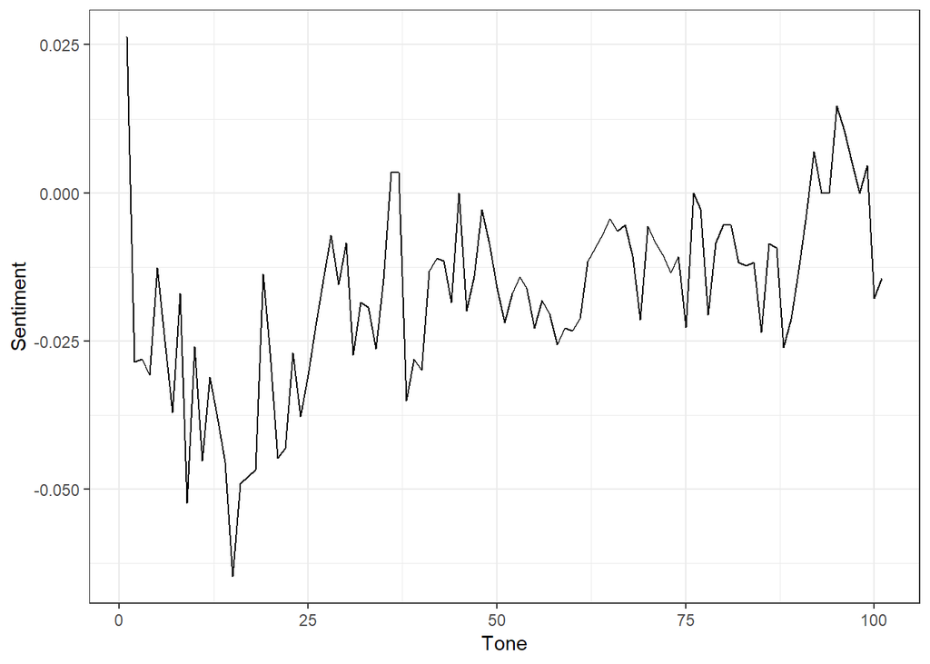

```r
# Line plot to visualize the evolvement of sentiment scores. This is especially helpful when studying a time series of sentiment scores.




plotSentiment(sentiment, xlab="Tone")
```

Conclusion: The Sentiment score is the lowest in the period from 2008 and 2009. The observation *correlates* to the recession during 2008 where market collapsed.

```r
Sentiment<-data.frame(fomcX$date,fomcX$year,sentiment$SentimentLM,convertToDirection(sentiment$SentimentLM))

names(Sentiment)<-(c("FOMC_Date","FOMC_Year","Sentiment_Score","Sentiment"))


# Structure before date type change

str(Sentiment)
```

```
## 'data.frame':    101 obs. of  4 variables:
##  $ FOMC_Date      : Factor w/ 101 levels "20070131","20070321",..: 1 2 3 4 5 6 7 8 9 10 ...
##  $ FOMC_Year      : num  2007 2007 2007 2007 2007 ...
##  $ Sentiment_Score: num  0.0263 -0.0286 -0.028 -0.0308 -0.0127 ...
##  $ Sentiment      : Factor w/ 3 levels "negative","neutral",..: 3 1 1 1 1 1 1 1 1 1 ...
```

```r
# Change the date format to Ymd
Sentiment$FOMC_Date<- ymd(Sentiment$FOMC_Date)

# Change the Year format

Sentiment$FOMC_Year<- as.numeric(Sentiment$FOMC_Year)

# Structure after date type change

str(Sentiment)
```

```
## 'data.frame':    101 obs. of  4 variables:
##  $ FOMC_Date      : Date, format: "2007-01-31" "2007-03-21" ...
##  $ FOMC_Year      : num  2007 2007 2007 2007 2007 ...
##  $ Sentiment_Score: num  0.0263 -0.0286 -0.028 -0.0308 -0.0127 ...
##  $ Sentiment      : Factor w/ 3 levels "negative","neutral",..: 3 1 1 1 1 1 1 1 1 1 ...
```

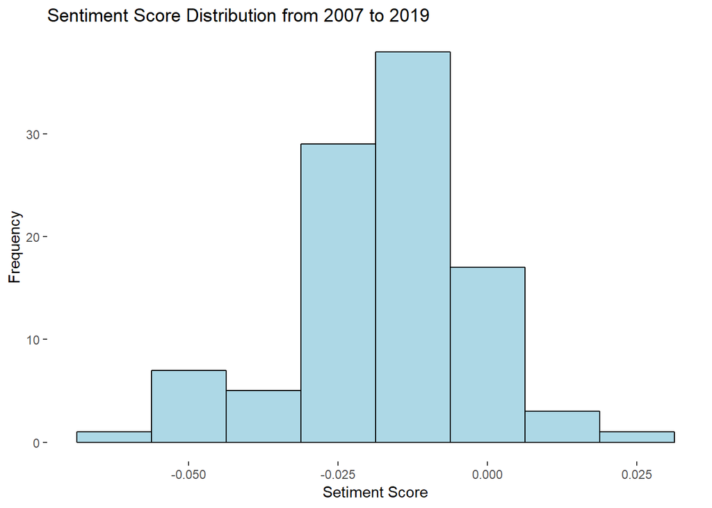

```r
# Distribution of Sentiment Score for period of 2007 to 2019


ggplot(Sentiment,aes(x=Sentiment_Score))+
  geom_histogram(binwidth =.0125,color="black",fill="lightblue")+
  labs(x="Setiment Score",y="Frequency",title="Sentiment Score Distribution from 2007 to 2019")+
   theme(panel.background = element_rect(fill = "white"))
```

The Overall sentiment frequency is towards negative than Positive score

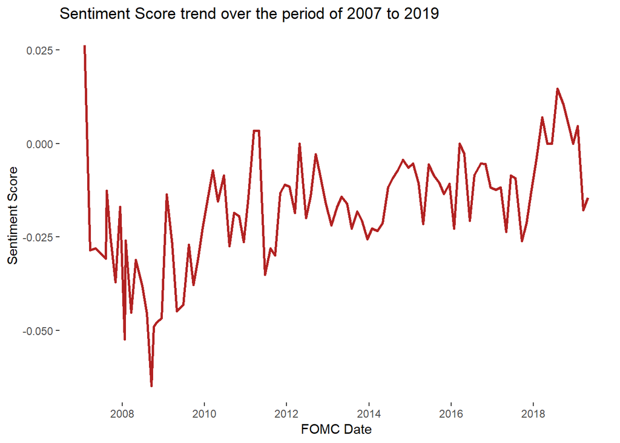

```r
# Sentiment Score Trend

ggplot(data = Sentiment)+
  aes(x=FOMC_Date,y=Sentiment_Score)+
  geom_line(size=.98,color="firebrick")+
  labs(x="FOMC Date",y="Sentiment Score",title="Sentiment Score trend over the period of 2007 to 2019")+
   theme(panel.background = element_rect(fill = "white"))
```

The Sentiment score is the lowest in the period from 2008 and 2009. The observation corelates to the recession during 2008 where market collapsed.

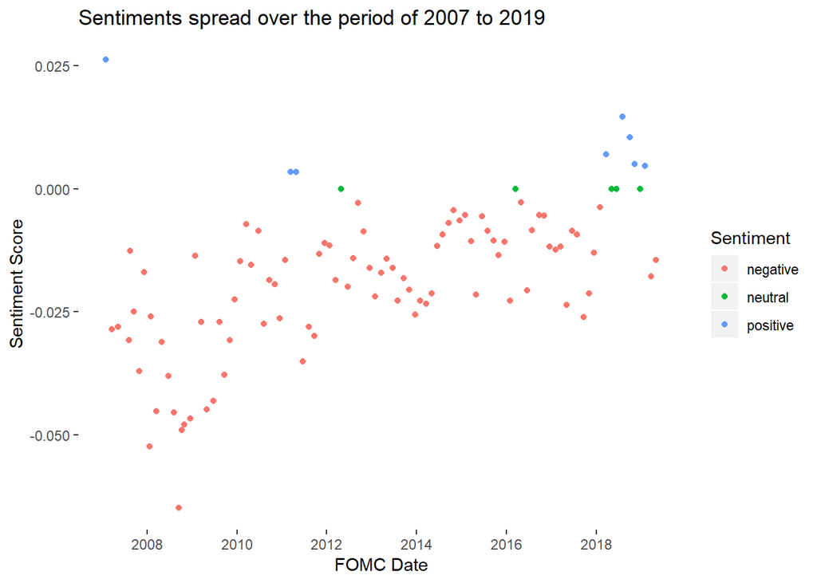

```r
# Scatter plot of score vs Date

## Grouped

ggplot(Sentiment,aes(x=FOMC_Date,y=Sentiment_Score,color=Sentiment))+
  geom_point()+
  labs(x="FOMC Date",y="Sentiment Score",title="Sentiments spread over the period of 2007 to 2019")+
   theme(panel.background = element_rect(fill = "white"))
```

The chart shows the spread of negative sentiment throughtout the time period from 2008 to 2015, followed by the neutral and positive sentiment.

```r
# Exporting data frame to RDS
## Changing the Date format
Sentiment$FOMC_Date<-format(Sentiment$FOMC_Date, format = "%Y%m%d")
## Exporting to .RDS
saveRDS(Sentiment,"SentimentDF.rds")
```

## 5.4 Financial Impact of Sentiment

### 5.4.1 Sentiment and Equity Markets

```r
# First load all 3 files into data frames.
# ------------------------------------------------------
mgData<-readRDS(file = "fomc_merged_data_v2.rds")
sData <- readRDS( file = "../DATA/SentimentDF.rds")
file_fred_ru1000tr = "https://raw.githubusercontent.com/completegraph/DATA607FINAL/master/DATA/FRED_RU1000TR.csv"
ru1000tr = read_csv(file_fred_ru1000tr,
                    col_types = cols(DATE=col_character(),
                                     RU1000TR = col_double() ) )
# Generate a lubridate date column to join with the FOMC data.
# -----------------------------------------------------------------
ru1000tr %>% mutate( date_mdy = lubridate::ymd( DATE ) )-> ruData
 #z_ru_daily = (RU1000TR - mean(RU1000TR, na.rm=TRUE))/sd(RU1000TR, na.rm = TRUE )
#  Second, join the data:
#  Since this is a 2-way inner join, we start with the FOMC statement data
#  and join it to the sentiment data by date string (yyyymmdd)
# -------------------------------------------------------------------------
mgData %>% inner_join(sData, by = c( "statement.dates" = "FOMC_Date")) -> msData
#  Join the sentiment-FOMC data to the Russell 1000 Index data from FRED
#  Make sure to add a Z-score for each of the time series: sentiment and Rusell index values
#     Save the raw data and normalized data by FOMC data.
# ----------------------------------------------------------------------------------
msEQdata = msData %>% left_join(ruData, by = c("date_mdy" = "date_mdy") ) %>%
                    select( date_mdy, Sentiment_Score, RU1000TR ) %>%
                    mutate( z_ru_fomc = (RU1000TR - mean(RU1000TR, na.rm = TRUE) ) / sd( RU1000TR, na.rm=TRUE ) ,
                            z_sentiment = ( Sentiment_Score - mean( Sentiment_Score, na.rm = TRUE) ) /
                              sd( Sentiment_Score, na.rm=TRUE) )
```

### 5.4.2 Data Transformation: Scale and Frequency Domain Issues

Let’s inspect the data for accuracy and scaling issues. Exploratory data analysis shows 3 issues.

- Normalization to z-score format is needed to ensure that scale is not a problem. Since the Russell Index level are expressed in the thousands, while the sentiment is on expressed in units of 0.01, scaling is essential along the y-dimension. To solve the scale problem, we convert the entire sample to Z-score equivalent which bring both time series to the same order of magnitude and mean.
- There is also a need to normalize in the frequency domain. FOMC meetings occur 8 times per year so their sentiment levels and changes reflect nearly 2 months of news. Russell equity index levels are collected on a daily basis in order to ensure completeness of the data collection. The volatility of lower frequency data is much greater in absolute terms than volatility of higher frequency (daily) data. To address this, we only calculate Z-scores of the Russell equity index levels observed **only** on the FOMC dates.
- Lastly, Russell Index levels increases at a geometric rate (roughly). Thus, values at the start of the sample period are smaller than values at the end of the period. The residuals in a regression of such data show significant increase volatility over the sample period. This is solved by apply a logarithmic transformation to Russell Index levels. This change fixes the non-constant residual volatility and also improves the model fit from 36 to 39 percent adjusted R-squared roughly.

The following code produces the log-transformed z-scores of FOMC periodic equity values.

```r
msEQdata %>% mutate( logEquity = log(RU1000TR) ) %>%
             mutate( z_logEquity = ( logEquity - mean(logEquity) )/ sd( logEquity ) ) -> msEQdata

msEQdata %>%  kable() %>% scroll_box(width="100%", height="200px")
```

| date_mdy | Sentiment_Score | RU1000TR | z_ru_fomc | z_sentiment | logEquity | z_logEquity |
| --- | --- | --- | --- | --- | --- | --- |
| 2007-01-31 | 0.0263158 | 3497.78 | -0.7169469 | 2.8673178 | 8.159884 | -0.6473283 |
| 2007-03-21 | -0.0285714 | 3505.86 | -0.7129262 | -0.7435143 | 8.162191 | -0.6416587 |
| 2007-05-09 | -0.0280374 | 3698.71 | -0.6169627 | -0.7083814 | 8.215739 | -0.5100826 |
| 2007-08-07 | -0.0307692 | 3610.26 | -0.6609760 | -0.8880998 | 8.191535 | -0.5695562 |
| 2007-08-17 | -0.0126582 | 3531.38 | -0.7002273 | 0.3033577 | 8.169444 | -0.6238373 |
| 2007-09-18 | -0.0250000 | 3726.95 | -0.6029103 | -0.5085629 | 8.223346 | -0.4913932 |
| 2007-10-31 | -0.0370370 | 3816.32 | -0.5584391 | -1.3004362 | 8.247042 | -0.4331676 |
| 2007-12-11 | -0.0169492 | 3650.86 | -0.6407732 | 0.0210733 | 8.202718 | -0.5420780 |
| 2008-01-22 | -0.0522876 | 3234.17 | -0.8481211 | -2.3037145 | 8.081528 | -0.8398612 |
| 2008-01-30 | -0.0259740 | 3353.44 | -0.7887715 | -0.5726406 | 8.117742 | -0.7508770 |
| 2008-03-18 | -0.0451977 | 3299.30 | -0.8157120 | -1.8372994 | 8.101466 | -0.7908705 |
| 2008-04-30 | -0.0310881 | 3452.16 | -0.7396477 | -0.9090759 | 8.146755 | -0.6795866 |
| 2008-06-25 | -0.0379747 | 3328.66 | -0.8011022 | -1.3621206 | 8.110325 | -0.7691014 |
| 2008-08-05 | -0.0454545 | 3219.69 | -0.8553265 | -1.8541937 | 8.077040 | -0.8508870 |
| 2008-09-16 | -0.0647482 | 3047.69 | -0.9409149 | -3.1234537 | 8.022139 | -0.9857875 |
| 2008-10-08 | -0.0490566 | 2454.63 | -1.2360259 | -2.0911601 | 7.805731 | -1.5175344 |
| 2008-10-29 | -0.0478723 | 2309.41 | -1.3082884 | -2.0132517 | 7.744747 | -1.6673812 |
| 2008-12-16 | -0.0466926 | 2277.87 | -1.3239829 | -1.9356413 | 7.730996 | -1.7011701 |
| 2009-01-28 | -0.0136519 | 2201.85 | -1.3618110 | 0.2379891 | 7.697053 | -1.7845729 |
| 2009-03-18 | -0.0270270 | 2016.35 | -1.4541171 | -0.6419137 | 7.609044 | -2.0008243 |
| 2009-04-29 | -0.0447761 | 2234.29 | -1.3456686 | -1.8095625 | 7.711679 | -1.7486357 |
| 2009-06-24 | -0.0430622 | 2311.77 | -1.3071140 | -1.6968100 | 7.745769 | -1.6648715 |
| 2009-08-12 | -0.0270270 | 2597.64 | -1.1648630 | -0.6419137 | 7.862359 | -1.3783925 |
| 2009-09-23 | -0.0377358 | 2751.63 | -1.0882365 | -1.3464085 | 7.919949 | -1.2368849 |
| 2009-11-04 | -0.0307167 | 2711.23 | -1.1083398 | -0.8846455 | 7.905158 | -1.2732287 |
| 2009-12-16 | -0.0224719 | 2889.67 | -1.0195468 | -0.3422490 | 7.968898 | -1.1166102 |
| 2010-01-27 | -0.0146628 | 2868.68 | -1.0299916 | 0.1714870 | 7.961607 | -1.1345236 |
| 2010-03-16 | -0.0071942 | 3049.00 | -0.9402631 | 0.6628135 | 8.022569 | -0.9847315 |
| 2010-04-28 | -0.0154440 | 3143.24 | -0.8933686 | 0.1200908 | 8.053009 | -0.9099347 |
| 2010-06-23 | -0.0084746 | 2886.76 | -1.0209949 | 0.5785851 | 7.967890 | -1.1190859 |

[output cut: 71 more lines]

### 5.4.3 Charting the Time Series Alternatives

In this section, we will show 3 time series charts illustrating the alternative considerations of regression modeling.

The first chart below shows the raw sentiment compared to raw Russell equity levels. Scale issues are obvious since the sentiment values are compressed to the appearance of a slightly fuzzy flat line. The chart below shows scaling is essential.

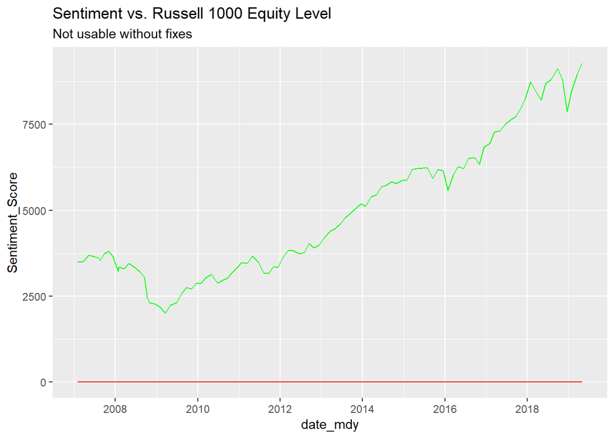

```r
ggplot() +
  geom_line(data=msEQdata, aes(x=date_mdy, y=Sentiment_Score) , color = "red" ) +
  geom_line(data=msEQdata, aes(x=date_mdy, y=RU1000TR), color="green") +
  ggtitle("Sentiment vs. Russell 1000 Equity Level", subtitle="Not usable without fixes")
```

The second chart shows the use of scaled sentiment versus scaled Russell equity levels. Scale issues are remain because the right hand side (the more recent years) shows higher variation than the left hand side (earliest years).

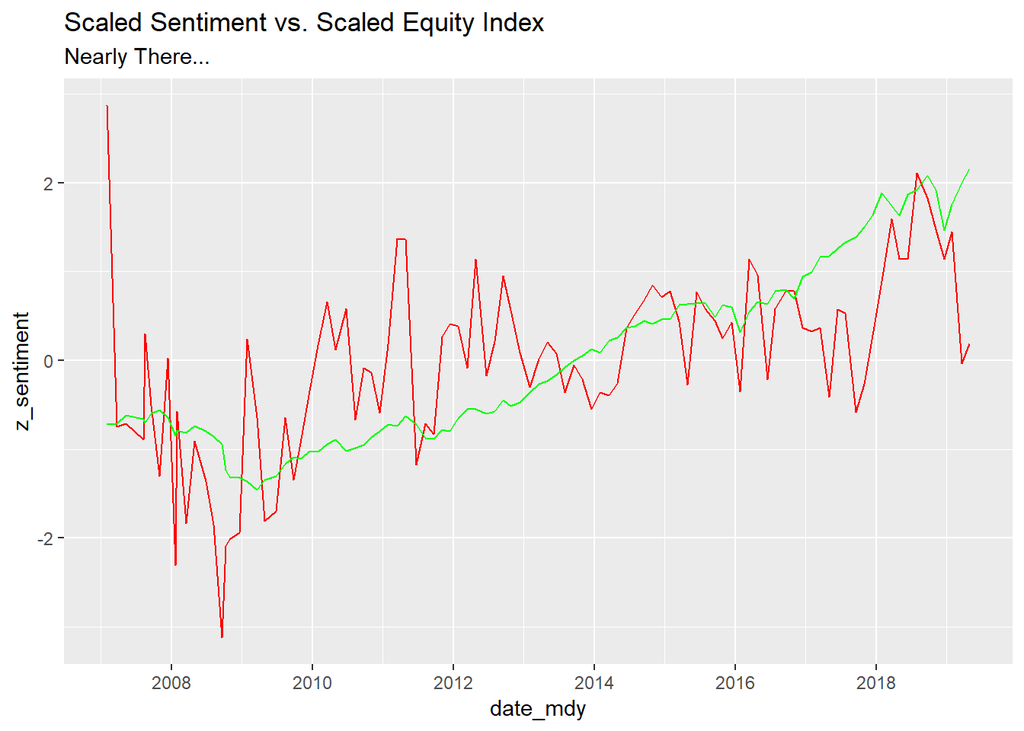

```r
ggplot() +
  geom_line(data=msEQdata, aes(x=date_mdy, y=z_sentiment) , color = "red" ) +
  geom_line(data=msEQdata, aes(x=date_mdy, y=z_ru_fomc), color="green") +
  ggtitle("Scaled Sentiment vs. Scaled Equity Index", subtitle = "Nearly There...")
```

Finally, the third chart shows the variables we will use in the regression analysis.

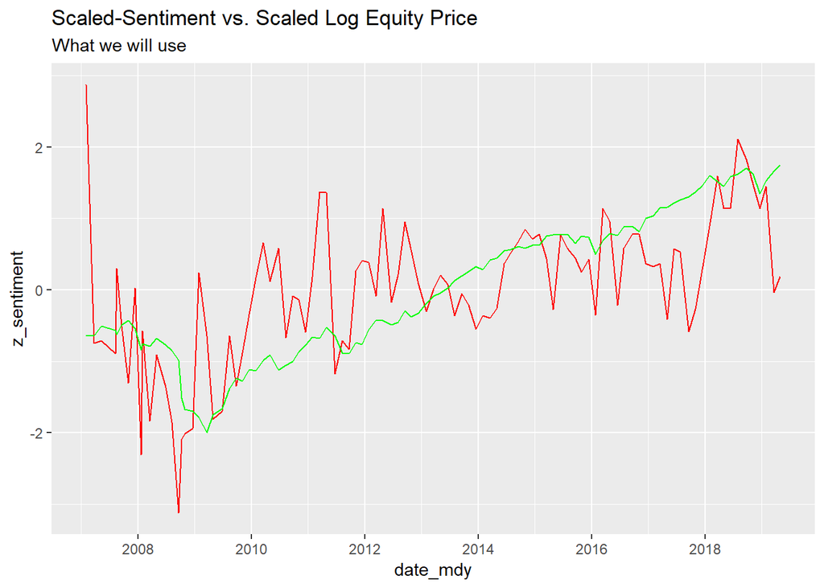

```r
ggplot() +
  geom_line(data=msEQdata, aes(x=date_mdy, y=z_sentiment) , color = "red" ) +
  geom_line(data=msEQdata, aes(x=date_mdy, y=z_logEquity), color="green") +
  ggtitle("Scaled-Sentiment vs. Scaled Log Equity Price", subtitle="What we will use")
```

### 5.4.4 Regressing Sentiment to Financial Variables

The final regression model we present uses the scaled, log-transformed data with the removal of an influential outlier (observation 1 of Jan 2007). For a reason yet to be determined, Jan 2007 generates the highest sentiment of the entire observation period. This is arguably wrong as the Sept 2018 period was possibly the most euphoric in recent memory. It is calculated in the code chunk below.

```r
mod1 = lm( z_logEquity ~ z_sentiment, data=msEQdata[2:102,])
summary(mod1)
```

```
##
## Call:
## lm(formula = z_logEquity ~ z_sentiment, data = msEQdata[2:102,
##     ])
##
## Residuals:
##      Min       1Q   Median       3Q      Max
## -1.96400 -0.58297  0.09103  0.56555  1.65740
##
## Coefficients:
##             Estimate Std. Error t value Pr(>|t|)
## (Intercept)  0.02507    0.07893   0.318    0.751
## z_sentiment  0.64857    0.08239   7.872 4.76e-12 ***
## ---
## Signif. codes:  0 '***' 0.001 '**' 0.01 '*' 0.05 '.' 0.1 ' ' 1
##
## Residual standard error: 0.789 on 98 degrees of freedom
##   (1 observation deleted due to missingness)
## Multiple R-squared:  0.3874, Adjusted R-squared:  0.3811
## F-statistic: 61.96 on 1 and 98 DF,  p-value: 4.761e-12
```

Examining the diagnostic plots below shows:

- Q-Q plot and histogram of residuals show reasonable approximation to normality.
- residuals have relatively homogenous variance across the range of observations
- residuals have little trend in relative to the fitted values
- leverage plot has controlled for most influential outlier (observation 1)

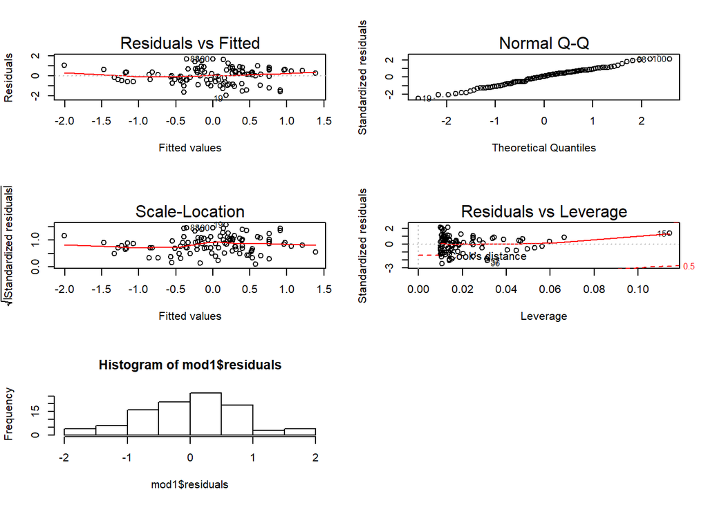

```r
par(mfrow=c(3,2))
plot(mod1)
hist(mod1$residuals )
```

Finally, we present the scatterplot of regressed values overlay with the regression line to study the model fit.

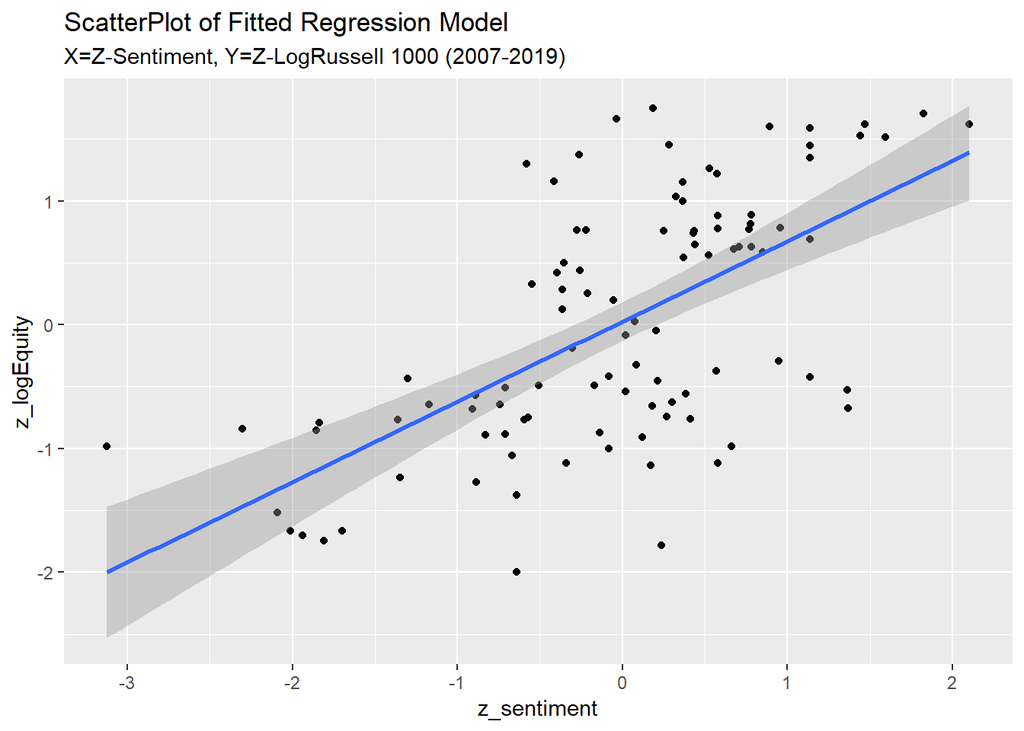

```r
ggplot(data=msEQdata[2:102,], aes(x=z_sentiment, y=z_logEquity) ) +
   geom_point() +
   geom_smooth(method=lm) +
   ggtitle("ScatterPlot of Fitted Regression Model", subtitle="X=Z-Sentiment, Y=Z-LogRussell 1000 (2007-2019)")
```

### 5.4.5 Discussion of Results

There are two comments related to the time series and regression we should make.

However, the sentiment index is imperfect. The 2013 taper tantrum is not reflected correctly from a bond investor point of view. As we recall, on May 22, 2013, bond markets panicked when Bernanke gave a speech to Congress that quantitative easing would likely be terminated at a future date. More investigation is needed to understand the market and FOMC dynamics around that historical episode and we regard this as future work.

Second, the regressions suggests that sentiment is positively associated with equity levels. Positive sentiment is associated with higher Russell Index 1000 levels. We think this makes sense. Whether sentiment causes equity markets to move or vice versa is too complex to answer with the crude econometric analysis we have conducted. However, the trend and regression results suggest that more detailed regression analysis of sentiment difference vs. equity returns (instead of levels) both contemporaneous or lagged would promising some predictive value from sentiment analysis. The project timeline did not allow for this more extensive regression analysis work, but we view it as fertile ground for future research.

# 6. Discussion of Results and Impact

We have discussed the results of our two analyses previously. This section focuses on broader considerations of the of FOMC statement analysis. How useful were the results in practical terms? First, the training and classification of FOMC statement attributes is clearly feasible. Our efforts combining laborious human review of the statements for labelling purposes with traditional supervised learning methods can produce useful prediction for some attributes. Other attributes such as inflation are not easily predicted using our approach. This does not mean that the problem cannot be solved with this line of attack.

Second, sentiment analysis is likely to be the more impactful tool in forecasting for investment management purposes. Our preliminary results, effectively a conventional approach to sentiment analysis, yielded a realistic looking financial sentiment indicator. We demonstrate some moderate level of explanatory power of sentiment and equity market levels using a linear regression. Much more extension regression analyses covering first differences of sentiment and price series is required. We believe the results are insufficient to be useful in practice but sufficient to justify further refinement and investigation to unlock value.

# 7. Conclusion

The project analyzed the FOMC statements using text based methods. The results are encouraging but not definitive in their utility. A much longer programme of research would be needed to explore the implications of this work. Others have gone done this path. Some companies such as JPMorgan Chase, BlackRock have dedicated teams to analyze interest rate markets and central bank communications with machine learning tools. One company called Prattle (www.prattle.co) has even commercialized this idea and provides central bank sentiment analysis for 16 central banks including the Fed. Therefore, we are on the right path – one led by earlier pioneers.

# 8. Reference

# Section 8: References

- Brusa, Francesca, Pavel Savor, and Mungo Wilson, “One Central Bank to Rule Them All”, working paper, 2015, Oxford University [https://papers.ssrn.com/sol3/papers.cfm?abstract_id=2658953]
- Cieslak, Anna and Morse, Adair and Annette Vissing-Jorgensen, “Stock Returns Over the FOMC Cycle”, Journal of Finance, forthcoming, [https://papers.ssrn.com/sol3/papers.cfm?abstract_id=2687614]
- Cannon, San, “Sentiment of the FOMC: Unscripted”, 2015, [https://www.kansascityfed.org/~/media/files/publicat/econrev/econrevarchive/2015/4q15cannon.pdf]
- Fuka, Michel and Didier Sornette “The Sentiment of the Fed”, 2013, [https://papers.ssrn.com/sol3/papers.cfm?abstract_id=2191937]
- Lucca, David and Francesco Trebbia, “Measuring Central Bank Communication: An Automated Approach with Application to FOMC Statements”, 2011, [http://faculty.arts.ubc.ca/ftrebbi/research/lt.pdf]